# Risk Factor Analysis

## Outcome Variable

**Outcome Variable:** ever_wasted

## Predictor Variables

**Intervention Variable:** fage

**Adjustment Set:**

- arm
- W_mage
- meducyrs
- feducyrs
- W_mhtcm
- W_mwtkg
- W_mbmi
- W_fhtcm
- single
- brthmon
- delta_W_mage
- delta_meducyrs
- delta_feducyrs
- delta_W_mhtcm
- delta_W_mwtkg
- delta_W_mbmi
- delta_W_fhtcm
- delta_single
- delta_brthmon

## Stratifying Variables

The analysis was stratified on these variable(s):

- agecat
- studyid
- country

## Data Summary

| agecat | studyid | country | fage | ever_wasted | n_cell | n |
| --- | --- | --- | --- | --- | --- | --- |
| 0-24 months | COHORTS | GUATEMALA | >=38 | 0 | 285 | 1285 |
| 0-24 months | COHORTS | GUATEMALA | >=38 | 1 | 97 | 1285 |
| 0-24 months | COHORTS | GUATEMALA | <32 | 0 | 453 | 1285 |
| 0-24 months | COHORTS | GUATEMALA | <32 | 1 | 148 | 1285 |
| 0-24 months | COHORTS | GUATEMALA | [32-38) | 0 | 218 | 1285 |
| 0-24 months | COHORTS | GUATEMALA | [32-38) | 1 | 84 | 1285 |
| 0-24 months | COHORTS | PHILIPPINES | >=38 | 0 | 191 | 2939 |
| 0-24 months | COHORTS | PHILIPPINES | >=38 | 1 | 137 | 2939 |
| 0-24 months | COHORTS | PHILIPPINES | <32 | 0 | 1235 | 2939 |
| 0-24 months | COHORTS | PHILIPPINES | <32 | 1 | 839 | 2939 |
| 0-24 months | COHORTS | PHILIPPINES | [32-38) | 0 | 332 | 2939 |
| 0-24 months | COHORTS | PHILIPPINES | [32-38) | 1 | 205 | 2939 |
| 0-24 months | LCNI-5 | MALAWI | >=38 | 0 | 24 | 106 |
| 0-24 months | LCNI-5 | MALAWI | >=38 | 1 | 2 | 106 |
| 0-24 months | LCNI-5 | MALAWI | <32 | 0 | 49 | 106 |
| 0-24 months | LCNI-5 | MALAWI | <32 | 1 | 7 | 106 |
| 0-24 months | LCNI-5 | MALAWI | [32-38) | 0 | 22 | 106 |
| 0-24 months | LCNI-5 | MALAWI | [32-38) | 1 | 2 | 106 |
| 0-24 months | MAL-ED | BANGLADESH | >=38 | 0 | 46 | 151 |
| 0-24 months | MAL-ED | BANGLADESH | >=38 | 1 | 23 | 151 |
| 0-24 months | MAL-ED | BANGLADESH | <32 | 0 | 15 | 151 |
| 0-24 months | MAL-ED | BANGLADESH | <32 | 1 | 15 | 151 |
| 0-24 months | MAL-ED | BANGLADESH | [32-38) | 0 | 39 | 151 |
| 0-24 months | MAL-ED | BANGLADESH | [32-38) | 1 | 13 | 151 |
| 0-24 months | MAL-ED | BRAZIL | >=38 | 0 | 30 | 79 |
| 0-24 months | MAL-ED | BRAZIL | >=38 | 1 | 0 | 79 |
| 0-24 months | MAL-ED | BRAZIL | <32 | 0 | 15 | 79 |
| 0-24 months | MAL-ED | BRAZIL | <32 | 1 | 3 | 79 |
| 0-24 months | MAL-ED | BRAZIL | [32-38) | 0 | 28 | 79 |
| 0-24 months | MAL-ED | BRAZIL | [32-38) | 1 | 3 | 79 |

[output cut: 204 more lines]

The following strata were considered:

- agecat: 0-24 months, studyid: COHORTS, country: GUATEMALA
- agecat: 0-24 months, studyid: COHORTS, country: PHILIPPINES
- agecat: 0-24 months, studyid: LCNI-5, country: MALAWI
- agecat: 0-24 months, studyid: MAL-ED, country: BANGLADESH
- agecat: 0-24 months, studyid: MAL-ED, country: BRAZIL
- agecat: 0-24 months, studyid: MAL-ED, country: INDIA
- agecat: 0-24 months, studyid: MAL-ED, country: NEPAL
- agecat: 0-24 months, studyid: MAL-ED, country: PERU
- agecat: 0-24 months, studyid: MAL-ED, country: SOUTH AFRICA
- agecat: 0-24 months, studyid: MAL-ED, country: TANZANIA, UNITED REPUBLIC OF
- agecat: 0-24 months, studyid: PROBIT, country: BELARUS
- agecat: 0-24 months, studyid: SAS-CompFeed, country: INDIA
- agecat: 0-24 months, studyid: SAS-FoodSuppl, country: INDIA
- agecat: 0-6 months, studyid: COHORTS, country: GUATEMALA
- agecat: 0-6 months, studyid: COHORTS, country: PHILIPPINES
- agecat: 0-6 months, studyid: LCNI-5, country: MALAWI
- agecat: 0-6 months, studyid: MAL-ED, country: BANGLADESH
- agecat: 0-6 months, studyid: MAL-ED, country: BRAZIL
- agecat: 0-6 months, studyid: MAL-ED, country: INDIA
- agecat: 0-6 months, studyid: MAL-ED, country: NEPAL
- agecat: 0-6 months, studyid: MAL-ED, country: PERU
- agecat: 0-6 months, studyid: MAL-ED, country: SOUTH AFRICA
- agecat: 0-6 months, studyid: MAL-ED, country: TANZANIA, UNITED REPUBLIC OF
- agecat: 0-6 months, studyid: PROBIT, country: BELARUS
- agecat: 0-6 months, studyid: SAS-CompFeed, country: INDIA
- agecat: 0-6 months, studyid: SAS-FoodSuppl, country: INDIA
- agecat: 6-24 months, studyid: COHORTS, country: GUATEMALA
- agecat: 6-24 months, studyid: COHORTS, country: PHILIPPINES
- agecat: 6-24 months, studyid: LCNI-5, country: MALAWI
- agecat: 6-24 months, studyid: MAL-ED, country: BANGLADESH
- agecat: 6-24 months, studyid: MAL-ED, country: BRAZIL
- agecat: 6-24 months, studyid: MAL-ED, country: INDIA
- agecat: 6-24 months, studyid: MAL-ED, country: NEPAL
- agecat: 6-24 months, studyid: MAL-ED, country: PERU
- agecat: 6-24 months, studyid: MAL-ED, country: SOUTH AFRICA
- agecat: 6-24 months, studyid: MAL-ED, country: TANZANIA, UNITED REPUBLIC OF
- agecat: 6-24 months, studyid: PROBIT, country: BELARUS
- agecat: 6-24 months, studyid: SAS-CompFeed, country: INDIA
- agecat: 6-24 months, studyid: SAS-FoodSuppl, country: INDIA

### Dropped Strata

Some strata were dropped due to rare outcomes:

- agecat: 0-24 months, studyid: LCNI-5, country: MALAWI
- agecat: 0-24 months, studyid: MAL-ED, country: BRAZIL
- agecat: 0-24 months, studyid: MAL-ED, country: NEPAL
- agecat: 0-24 months, studyid: MAL-ED, country: PERU
- agecat: 0-24 months, studyid: MAL-ED, country: SOUTH AFRICA
- agecat: 0-24 months, studyid: MAL-ED, country: TANZANIA, UNITED REPUBLIC OF
- agecat: 0-6 months, studyid: LCNI-5, country: MALAWI
- agecat: 0-6 months, studyid: MAL-ED, country: BRAZIL
- agecat: 0-6 months, studyid: MAL-ED, country: NEPAL
- agecat: 0-6 months, studyid: MAL-ED, country: PERU
- agecat: 0-6 months, studyid: MAL-ED, country: SOUTH AFRICA
- agecat: 0-6 months, studyid: MAL-ED, country: TANZANIA, UNITED REPUBLIC OF
- agecat: 6-24 months, studyid: LCNI-5, country: MALAWI
- agecat: 6-24 months, studyid: MAL-ED, country: BRAZIL
- agecat: 6-24 months, studyid: MAL-ED, country: NEPAL
- agecat: 6-24 months, studyid: MAL-ED, country: PERU
- agecat: 6-24 months, studyid: MAL-ED, country: SOUTH AFRICA
- agecat: 6-24 months, studyid: MAL-ED, country: TANZANIA, UNITED REPUBLIC OF

## Methods Detail

We're interested in the causal parameters $E[Y_a]$ for all values of $a \in \mathcal{A}$. These parameters represent the mean outcome if, possibly contrary to fact, we intervened to set all units to have $A=a$. Under the randomization and positivity assumptions, these are identified by the statistical parameters $\psi_a=E_W[E_{Y|A,W}(Y|A=a,W)]$. In addition, we're interested in the mean of $Y$, $E[Y]$ under no intervention (the observed mean). We will estimate these parameters by using SuperLearner to fit the relevant likelihood factors -- $E_{Y|A,W}(Y|A=a,W)$ and $p(A=a|W)$, and then updating our likelihood fit using a joint TMLE.

For unadjusted analyses ($W=\{\}$), initial likelihoods were estimated using Lrnr_glm to estimate the simple $E(Y|A)$ and Lrnr_mean to estimate $p(A)$. For adjusted analyses, a small library containing Lrnr_glmnet, Lrnr_xgboost, and Lrnr_mean was used.

Having estimated these parameters, we will then use the delta method to estimate relative risks and attributable risks relative to a prespecified baseline level of $A$.

# Results Detail

## Results Plots

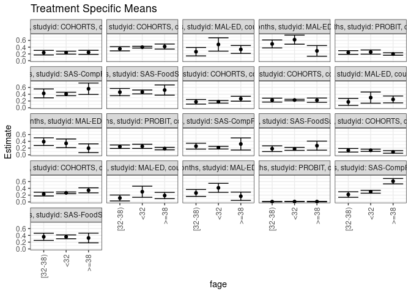

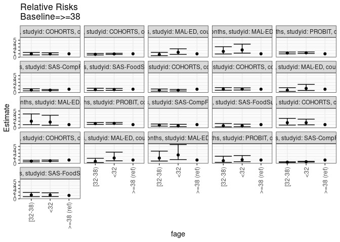

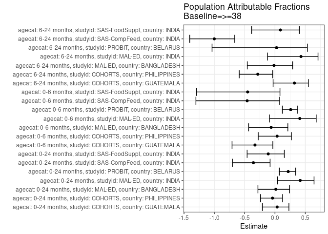

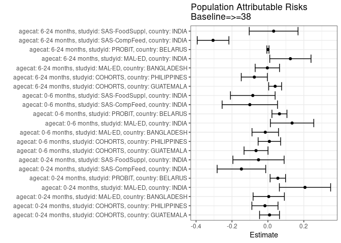

## Results Table

### Parameter: TSM

| agecat | studyid | country | intervention_level | baseline_level | estimate | ci_lower | ci_upper |
| --- | --- | --- | --- | --- | --- | --- | --- |
| 0-24 months | COHORTS | GUATEMALA | >=38 | NA | 0.2469161 | 0.1867819 | 0.3070502 |
| 0-24 months | COHORTS | GUATEMALA | <32 | NA | 0.2380866 | 0.1945499 | 0.2816232 |
| 0-24 months | COHORTS | GUATEMALA | [32-38) | NA | 0.2380126 | 0.1703851 | 0.3056401 |
| 0-24 months | COHORTS | PHILIPPINES | >=38 | NA | 0.4182597 | 0.3439998 | 0.4925196 |
| 0-24 months | COHORTS | PHILIPPINES | <32 | NA | 0.3991424 | 0.3729023 | 0.4253825 |
| 0-24 months | COHORTS | PHILIPPINES | [32-38) | NA | 0.3522083 | 0.2904798 | 0.4139367 |
| 0-24 months | MAL-ED | BANGLADESH | >=38 | NA | 0.3330476 | 0.2163883 | 0.4497070 |
| 0-24 months | MAL-ED | BANGLADESH | <32 | NA | 0.4801616 | 0.2826800 | 0.6776431 |
| 0-24 months | MAL-ED | BANGLADESH | [32-38) | NA | 0.2656788 | 0.1407275 | 0.3906301 |
| 0-24 months | MAL-ED | INDIA | >=38 | NA | 0.2902510 | 0.1324378 | 0.4480641 |
| 0-24 months | MAL-ED | INDIA | <32 | NA | 0.6214478 | 0.4879676 | 0.7549279 |
| 0-24 months | MAL-ED | INDIA | [32-38) | NA | 0.4950143 | 0.3777601 | 0.6122684 |
| 0-24 months | PROBIT | BELARUS | >=38 | NA | 0.1984604 | 0.1612471 | 0.2356737 |
| 0-24 months | PROBIT | BELARUS | <32 | NA | 0.2550566 | 0.1933362 | 0.3167769 |
| 0-24 months | PROBIT | BELARUS | [32-38) | NA | 0.2426938 | 0.1884814 | 0.2969062 |
| 0-24 months | SAS-CompFeed | INDIA | >=38 | NA | 0.5619996 | 0.3937456 | 0.7302536 |
| 0-24 months | SAS-CompFeed | INDIA | <32 | NA | 0.4072548 | 0.3554343 | 0.4590754 |
| 0-24 months | SAS-CompFeed | INDIA | [32-38) | NA | 0.4244577 | 0.2937446 | 0.5551709 |
| 0-24 months | SAS-FoodSuppl | INDIA | >=38 | NA | 0.5235680 | 0.3727017 | 0.6744342 |
| 0-24 months | SAS-FoodSuppl | INDIA | <32 | NA | 0.4672801 | 0.4095979 | 0.5249623 |
| 0-24 months | SAS-FoodSuppl | INDIA | [32-38) | NA | 0.4621463 | 0.3551150 | 0.5691777 |
| 0-6 months | COHORTS | GUATEMALA | >=38 | NA | 0.2666930 | 0.1942949 | 0.3390910 |
| 0-6 months | COHORTS | GUATEMALA | <32 | NA | 0.1756417 | 0.1372840 | 0.2139994 |
| 0-6 months | COHORTS | GUATEMALA | [32-38) | NA | 0.1761563 | 0.1077799 | 0.2445326 |
| 0-6 months | COHORTS | PHILIPPINES | >=38 | NA | 0.2238384 | 0.1599709 | 0.2877060 |
| 0-6 months | COHORTS | PHILIPPINES | <32 | NA | 0.2293752 | 0.2073228 | 0.2514277 |
| 0-6 months | COHORTS | PHILIPPINES | [32-38) | NA | 0.2258526 | 0.1685667 | 0.2831386 |
| 0-6 months | MAL-ED | BANGLADESH | >=38 | NA | 0.2463768 | 0.1443667 | 0.3483870 |
| 0-6 months | MAL-ED | BANGLADESH | <32 | NA | 0.3000000 | 0.1354719 | 0.4645281 |
| 0-6 months | MAL-ED | BANGLADESH | [32-38) | NA | 0.1730769 | 0.0699098 | 0.2762441 |
| 0-6 months | MAL-ED | INDIA | >=38 | NA | 0.1944444 | 0.0647578 | 0.3241311 |
| 0-6 months | MAL-ED | INDIA | <32 | NA | 0.3396226 | 0.2117265 | 0.4675188 |
| 0-6 months | MAL-ED | INDIA | [32-38) | NA | 0.3888889 | 0.2759333 | 0.5018445 |
| 0-6 months | PROBIT | BELARUS | >=38 | NA | 0.1841195 | 0.1479161 | 0.2203229 |
| 0-6 months | PROBIT | BELARUS | <32 | NA | 0.2500707 | 0.1883541 | 0.3117873 |
| 0-6 months | PROBIT | BELARUS | [32-38) | NA | 0.2399959 | 0.1885305 | 0.2914613 |
| 0-6 months | SAS-CompFeed | INDIA | >=38 | NA | 0.3203655 | 0.1419059 | 0.4988251 |
| 0-6 months | SAS-CompFeed | INDIA | <32 | NA | 0.2115571 | 0.1714884 | 0.2516257 |
| 0-6 months | SAS-CompFeed | INDIA | [32-38) | NA | 0.2558912 | 0.1689365 | 0.3428459 |
| 0-6 months | SAS-FoodSuppl | INDIA | >=38 | NA | 0.2707463 | 0.1375330 | 0.4039596 |
| 0-6 months | SAS-FoodSuppl | INDIA | <32 | NA | 0.1758547 | 0.1318641 | 0.2198453 |
| 0-6 months | SAS-FoodSuppl | INDIA | [32-38) | NA | 0.1810417 | 0.0970500 | 0.2650334 |
| 6-24 months | COHORTS | GUATEMALA | >=38 | NA | 0.0857892 | 0.0474373 | 0.1241412 |
| 6-24 months | COHORTS | GUATEMALA | <32 | NA | 0.1337967 | 0.1004063 | 0.1671870 |
| 6-24 months | COHORTS | GUATEMALA | [32-38) | NA | 0.1340086 | 0.0808642 | 0.1871529 |
| 6-24 months | COHORTS | PHILIPPINES | >=38 | NA | 0.3417091 | 0.2672119 | 0.4162063 |
| 6-24 months | COHORTS | PHILIPPINES | <32 | NA | 0.2669770 | 0.2413892 | 0.2925648 |
| 6-24 months | COHORTS | PHILIPPINES | [32-38) | NA | 0.2304903 | 0.1749967 | 0.2859840 |
| 6-24 months | MAL-ED | BANGLADESH | >=38 | NA | 0.1884058 | 0.0958331 | 0.2809785 |
| 6-24 months | MAL-ED | BANGLADESH | <32 | NA | 0.3000000 | 0.1354719 | 0.4645281 |
| 6-24 months | MAL-ED | BANGLADESH | [32-38) | NA | 0.1153846 | 0.0282601 | 0.2025091 |
| 6-24 months | MAL-ED | INDIA | >=38 | NA | 0.1666667 | 0.0445476 | 0.2887858 |
| 6-24 months | MAL-ED | INDIA | <32 | NA | 0.4150943 | 0.2820246 | 0.5481641 |
| 6-24 months | MAL-ED | INDIA | [32-38) | NA | 0.2638889 | 0.1617674 | 0.3660104 |
| 6-24 months | PROBIT | BELARUS | >=38 | NA | 0.0081633 | 0.0010716 | 0.0152549 |
| 6-24 months | PROBIT | BELARUS | <32 | NA | 0.0087439 | 0.0047147 | 0.0127730 |
| 6-24 months | PROBIT | BELARUS | [32-38) | NA | 0.0065359 | 0.0019147 | 0.0111572 |
| 6-24 months | SAS-CompFeed | INDIA | >=38 | NA | 0.6106108 | 0.5309083 | 0.6903133 |
| 6-24 months | SAS-CompFeed | INDIA | <32 | NA | 0.2996310 | 0.2567729 | 0.3424891 |
| 6-24 months | SAS-CompFeed | INDIA | [32-38) | NA | 0.2170291 | 0.1357884 | 0.2982697 |
| 6-24 months | SAS-FoodSuppl | INDIA | >=38 | NA | 0.3237172 | 0.1803410 | 0.4670933 |
| 6-24 months | SAS-FoodSuppl | INDIA | <32 | NA | 0.3581667 | 0.3017483 | 0.4145851 |
| 6-24 months | SAS-FoodSuppl | INDIA | [32-38) | NA | 0.3586971 | 0.2523299 | 0.4650642 |

### Parameter: E(Y)

| agecat | studyid | country | intervention_level | baseline_level | estimate | ci_lower | ci_upper |
| --- | --- | --- | --- | --- | --- | --- | --- |
| 0-24 months | COHORTS | GUATEMALA | NA | NA | 0.2560311 | 0.2321591 | 0.2799032 |
| 0-24 months | COHORTS | PHILIPPINES | NA | NA | 0.4018374 | 0.3841095 | 0.4195652 |
| 0-24 months | MAL-ED | BANGLADESH | NA | NA | 0.3377483 | 0.2620632 | 0.4134335 |
| 0-24 months | MAL-ED | INDIA | NA | NA | 0.4968944 | 0.4194215 | 0.5743673 |
| 0-24 months | PROBIT | BELARUS | NA | NA | 0.2538395 | 0.1952096 | 0.3124695 |
| 0-24 months | SAS-CompFeed | INDIA | NA | NA | 0.4145695 | 0.3576236 | 0.4715155 |
| 0-24 months | SAS-FoodSuppl | INDIA | NA | NA | 0.4712919 | 0.4233811 | 0.5192026 |
| 0-6 months | COHORTS | GUATEMALA | NA | NA | 0.2005842 | 0.1760818 | 0.2250867 |
| 0-6 months | COHORTS | PHILIPPINES | NA | NA | 0.2321307 | 0.2168619 | 0.2473995 |
| 0-6 months | MAL-ED | BANGLADESH | NA | NA | 0.2317881 | 0.1642594 | 0.2993168 |
| 0-6 months | MAL-ED | INDIA | NA | NA | 0.3291925 | 0.2563790 | 0.4020061 |
| 0-6 months | PROBIT | BELARUS | NA | NA | 0.2484793 | 0.1896843 | 0.3072742 |
| 0-6 months | SAS-CompFeed | INDIA | NA | NA | 0.2197071 | 0.1750081 | 0.2644060 |
| 0-6 months | SAS-FoodSuppl | INDIA | NA | NA | 0.1866029 | 0.1492099 | 0.2239959 |
| 6-24 months | COHORTS | GUATEMALA | NA | NA | 0.1261803 | 0.1071047 | 0.1452559 |
| 6-24 months | COHORTS | PHILIPPINES | NA | NA | 0.2661765 | 0.2495644 | 0.2827886 |
| 6-24 months | MAL-ED | BANGLADESH | NA | NA | 0.1854305 | 0.1232352 | 0.2476257 |
| 6-24 months | MAL-ED | INDIA | NA | NA | 0.2919255 | 0.2214783 | 0.3623726 |
| 6-24 months | PROBIT | BELARUS | NA | NA | 0.0083792 | 0.0045582 | 0.0122002 |
| 6-24 months | SAS-CompFeed | INDIA | NA | NA | 0.3051948 | 0.2633957 | 0.3469939 |
| 6-24 months | SAS-FoodSuppl | INDIA | NA | NA | 0.3557214 | 0.3088651 | 0.4025777 |

### Parameter: RR

| agecat | studyid | country | intervention_level | baseline_level | estimate | ci_lower | ci_upper |
| --- | --- | --- | --- | --- | --- | --- | --- |
| 0-24 months | COHORTS | GUATEMALA | >=38 | >=38 | 1.0000000 | 1.0000000 | 1.0000000 |
| 0-24 months | COHORTS | GUATEMALA | <32 | >=38 | 0.9642410 | 0.7118333 | 1.3061495 |
| 0-24 months | COHORTS | GUATEMALA | [32-38) | >=38 | 0.9639413 | 0.6637766 | 1.3998429 |
| 0-24 months | COHORTS | PHILIPPINES | >=38 | >=38 | 1.0000000 | 1.0000000 | 1.0000000 |
| 0-24 months | COHORTS | PHILIPPINES | <32 | >=38 | 0.9542934 | 0.7897223 | 1.1531595 |
| 0-24 months | COHORTS | PHILIPPINES | [32-38) | >=38 | 0.8420804 | 0.6561500 | 1.0806971 |
| 0-24 months | MAL-ED | BANGLADESH | >=38 | >=38 | 1.0000000 | 1.0000000 | 1.0000000 |
| 0-24 months | MAL-ED | BANGLADESH | <32 | >=38 | 1.4417203 | 0.8406082 | 2.4726828 |
| 0-24 months | MAL-ED | BANGLADESH | [32-38) | >=38 | 0.7977201 | 0.4446180 | 1.4312451 |
| 0-24 months | MAL-ED | INDIA | >=38 | >=38 | 1.0000000 | 1.0000000 | 1.0000000 |
| 0-24 months | MAL-ED | INDIA | <32 | >=38 | 2.1410705 | 1.1927234 | 3.8434585 |
| 0-24 months | MAL-ED | INDIA | [32-38) | >=38 | 1.7054698 | 0.9418804 | 3.0881070 |
| 0-24 months | PROBIT | BELARUS | >=38 | >=38 | 1.0000000 | 1.0000000 | 1.0000000 |
| 0-24 months | PROBIT | BELARUS | <32 | >=38 | 1.2851760 | 1.0708336 | 1.5424220 |
| 0-24 months | PROBIT | BELARUS | [32-38) | >=38 | 1.2228827 | 0.9871969 | 1.5148367 |
| 0-24 months | SAS-CompFeed | INDIA | >=38 | >=38 | 1.0000000 | 1.0000000 | 1.0000000 |
| 0-24 months | SAS-CompFeed | INDIA | <32 | >=38 | 0.7246533 | 0.5773474 | 0.9095430 |
| 0-24 months | SAS-CompFeed | INDIA | [32-38) | >=38 | 0.7552635 | 0.5094567 | 1.1196691 |
| 0-24 months | SAS-FoodSuppl | INDIA | >=38 | >=38 | 1.0000000 | 1.0000000 | 1.0000000 |
| 0-24 months | SAS-FoodSuppl | INDIA | <32 | >=38 | 0.8924917 | 0.6522578 | 1.2212065 |
| 0-24 months | SAS-FoodSuppl | INDIA | [32-38) | >=38 | 0.8826864 | 0.6098723 | 1.2775383 |
| 0-6 months | COHORTS | GUATEMALA | >=38 | >=38 | 1.0000000 | 1.0000000 | 1.0000000 |
| 0-6 months | COHORTS | GUATEMALA | <32 | >=38 | 0.6585914 | 0.4651049 | 0.9325695 |
| 0-6 months | COHORTS | GUATEMALA | [32-38) | >=38 | 0.6605208 | 0.4114430 | 1.0603844 |
| 0-6 months | COHORTS | PHILIPPINES | >=38 | >=38 | 1.0000000 | 1.0000000 | 1.0000000 |
| 0-6 months | COHORTS | PHILIPPINES | <32 | >=38 | 1.0247356 | 0.7582771 | 1.3848275 |
| 0-6 months | COHORTS | PHILIPPINES | [32-38) | >=38 | 1.0089985 | 0.6887696 | 1.4781109 |
| 0-6 months | MAL-ED | BANGLADESH | >=38 | >=38 | 1.0000000 | 1.0000000 | 1.0000000 |
| 0-6 months | MAL-ED | BANGLADESH | <32 | >=38 | 1.2176471 | 0.6124737 | 2.4207805 |
| 0-6 months | MAL-ED | BANGLADESH | [32-38) | >=38 | 0.7024887 | 0.3399717 | 1.4515632 |
| 0-6 months | MAL-ED | INDIA | >=38 | >=38 | 1.0000000 | 1.0000000 | 1.0000000 |
| 0-6 months | MAL-ED | INDIA | <32 | >=38 | 1.7466307 | 0.8120101 | 3.7569961 |
| 0-6 months | MAL-ED | INDIA | [32-38) | >=38 | 2.0000000 | 0.9662673 | 4.1396415 |
| 0-6 months | PROBIT | BELARUS | >=38 | >=38 | 1.0000000 | 1.0000000 | 1.0000000 |
| 0-6 months | PROBIT | BELARUS | <32 | >=38 | 1.3581978 | 1.1349595 | 1.6253455 |
| 0-6 months | PROBIT | BELARUS | [32-38) | >=38 | 1.3034791 | 1.0578853 | 1.6060888 |
| 0-6 months | SAS-CompFeed | INDIA | >=38 | >=38 | 1.0000000 | 1.0000000 | 1.0000000 |
| 0-6 months | SAS-CompFeed | INDIA | <32 | >=38 | 0.6603616 | 0.3987250 | 1.0936796 |
| 0-6 months | SAS-CompFeed | INDIA | [32-38) | >=38 | 0.7987476 | 0.5424115 | 1.1762247 |
| 0-6 months | SAS-FoodSuppl | INDIA | >=38 | >=38 | 1.0000000 | 1.0000000 | 1.0000000 |
| 0-6 months | SAS-FoodSuppl | INDIA | <32 | >=38 | 0.6495183 | 0.3738659 | 1.1284100 |
| 0-6 months | SAS-FoodSuppl | INDIA | [32-38) | >=38 | 0.6686765 | 0.3395196 | 1.3169438 |
| 6-24 months | COHORTS | GUATEMALA | >=38 | >=38 | 1.0000000 | 1.0000000 | 1.0000000 |
| 6-24 months | COHORTS | GUATEMALA | <32 | >=38 | 1.5595972 | 0.9348855 | 2.6017555 |
| 6-24 months | COHORTS | GUATEMALA | [32-38) | >=38 | 1.5620671 | 0.8603966 | 2.8359638 |
| 6-24 months | COHORTS | PHILIPPINES | >=38 | >=38 | 1.0000000 | 1.0000000 | 1.0000000 |
| 6-24 months | COHORTS | PHILIPPINES | <32 | >=38 | 0.7812991 | 0.6158159 | 0.9912512 |
| 6-24 months | COHORTS | PHILIPPINES | [32-38) | >=38 | 0.6745221 | 0.4874808 | 0.9333293 |
| 6-24 months | MAL-ED | BANGLADESH | >=38 | >=38 | 1.0000000 | 1.0000000 | 1.0000000 |
| 6-24 months | MAL-ED | BANGLADESH | <32 | >=38 | 1.5923077 | 0.7624990 | 3.3251767 |
| 6-24 months | MAL-ED | BANGLADESH | [32-38) | >=38 | 0.6124260 | 0.2487773 | 1.5076363 |
| 6-24 months | MAL-ED | INDIA | >=38 | >=38 | 1.0000000 | 1.0000000 | 1.0000000 |
| 6-24 months | MAL-ED | INDIA | <32 | >=38 | 2.4905660 | 1.1193351 | 5.5416104 |
| 6-24 months | MAL-ED | INDIA | [32-38) | >=38 | 1.5833333 | 0.6913573 | 3.6261201 |
| 6-24 months | PROBIT | BELARUS | >=38 | >=38 | 1.0000000 | 1.0000000 | 1.0000000 |
| 6-24 months | PROBIT | BELARUS | <32 | >=38 | 1.0711219 | 0.4964948 | 2.3108038 |
| 6-24 months | PROBIT | BELARUS | [32-38) | >=38 | 0.8006536 | 0.3030215 | 2.1155137 |
| 6-24 months | SAS-CompFeed | INDIA | >=38 | >=38 | 1.0000000 | 1.0000000 | 1.0000000 |
| 6-24 months | SAS-CompFeed | INDIA | <32 | >=38 | 0.4907070 | 0.3994595 | 0.6027981 |
| 6-24 months | SAS-CompFeed | INDIA | [32-38) | >=38 | 0.3554295 | 0.2586265 | 0.4884654 |
| 6-24 months | SAS-FoodSuppl | INDIA | >=38 | >=38 | 1.0000000 | 1.0000000 | 1.0000000 |
| 6-24 months | SAS-FoodSuppl | INDIA | <32 | >=38 | 1.1064187 | 0.6913402 | 1.7707090 |
| 6-24 months | SAS-FoodSuppl | INDIA | [32-38) | >=38 | 1.1080570 | 0.6503697 | 1.8878346 |

### Parameter: PAR

| agecat | studyid | country | intervention_level | baseline_level | estimate | ci_lower | ci_upper |
| --- | --- | --- | --- | --- | --- | --- | --- |
| 0-24 months | COHORTS | GUATEMALA | >=38 | NA | 0.0091151 | -0.0463974 | 0.0646276 |
| 0-24 months | COHORTS | PHILIPPINES | >=38 | NA | -0.0164223 | -0.0891586 | 0.0563140 |
| 0-24 months | MAL-ED | BANGLADESH | >=38 | NA | 0.0047007 | -0.0824405 | 0.0918419 |
| 0-24 months | MAL-ED | INDIA | >=38 | NA | 0.2066435 | 0.0639157 | 0.3493712 |
| 0-24 months | PROBIT | BELARUS | >=38 | NA | 0.0553791 | 0.0124314 | 0.0983269 |
| 0-24 months | SAS-CompFeed | INDIA | >=38 | NA | -0.1474300 | -0.2826795 | -0.0121805 |
| 0-24 months | SAS-FoodSuppl | INDIA | >=38 | NA | -0.0522761 | -0.1950086 | 0.0904564 |
| 0-6 months | COHORTS | GUATEMALA | >=38 | NA | -0.0661088 | -0.1328319 | 0.0006144 |
| 0-6 months | COHORTS | PHILIPPINES | >=38 | NA | 0.0082923 | -0.0544175 | 0.0710020 |
| 0-6 months | MAL-ED | BANGLADESH | >=38 | NA | -0.0145887 | -0.0884536 | 0.0592761 |
| 0-6 months | MAL-ED | INDIA | >=38 | NA | 0.1347481 | 0.0139215 | 0.2555747 |
| 0-6 months | PROBIT | BELARUS | >=38 | NA | 0.0643598 | 0.0225609 | 0.1061587 |
| 0-6 months | SAS-CompFeed | INDIA | >=38 | NA | -0.1006585 | -0.2549842 | 0.0536672 |
| 0-6 months | SAS-FoodSuppl | INDIA | >=38 | NA | -0.0841435 | -0.2085862 | 0.0402993 |
| 6-24 months | COHORTS | GUATEMALA | >=38 | NA | 0.0403910 | 0.0043817 | 0.0764003 |
| 6-24 months | COHORTS | PHILIPPINES | >=38 | NA | -0.0755326 | -0.1482938 | -0.0027715 |
| 6-24 months | MAL-ED | BANGLADESH | >=38 | NA | -0.0029753 | -0.0708431 | 0.0648925 |
| 6-24 months | MAL-ED | INDIA | >=38 | NA | 0.1252588 | 0.0103385 | 0.2401791 |
| 6-24 months | PROBIT | BELARUS | >=38 | NA | 0.0002159 | -0.0058072 | 0.0062391 |
| 6-24 months | SAS-CompFeed | INDIA | >=38 | NA | -0.3054160 | -0.3935477 | -0.2172843 |
| 6-24 months | SAS-FoodSuppl | INDIA | >=38 | NA | 0.0320042 | -0.1038747 | 0.1678832 |

### Parameter: PAF

| agecat | studyid | country | intervention_level | baseline_level | estimate | ci_lower | ci_upper |
| --- | --- | --- | --- | --- | --- | --- | --- |
| 0-24 months | COHORTS | GUATEMALA | >=38 | NA | 0.0356014 | -0.2075013 | 0.2297610 |
| 0-24 months | COHORTS | PHILIPPINES | >=38 | NA | -0.0408680 | -0.2386556 | 0.1253370 |
| 0-24 months | MAL-ED | BANGLADESH | >=38 | NA | 0.0139178 | -0.2811017 | 0.2409985 |
| 0-24 months | MAL-ED | INDIA | >=38 | NA | 0.4158699 | 0.0399409 | 0.6445969 |
| 0-24 months | PROBIT | BELARUS | >=38 | NA | 0.2181659 | 0.0719350 | 0.3413558 |
| 0-24 months | SAS-CompFeed | INDIA | >=38 | NA | -0.3556220 | -0.7012932 | -0.0801847 |
| 0-24 months | SAS-FoodSuppl | INDIA | >=38 | NA | -0.1109208 | -0.4592526 | 0.1542622 |
| 0-6 months | COHORTS | GUATEMALA | >=38 | NA | -0.3295811 | -0.7076737 | -0.0352011 |
| 0-6 months | COHORTS | PHILIPPINES | >=38 | NA | 0.0357223 | -0.2759366 | 0.2712558 |
| 0-6 months | MAL-ED | BANGLADESH | >=38 | NA | -0.0629400 | -0.4342828 | 0.2122604 |
| 0-6 months | MAL-ED | INDIA | >=38 | NA | 0.4093291 | -0.0907885 | 0.6801469 |
| 0-6 months | PROBIT | BELARUS | >=38 | NA | 0.2590147 | 0.1223991 | 0.3743634 |
| 0-6 months | SAS-CompFeed | INDIA | >=38 | NA | -0.4581485 | -1.3037938 | 0.0770888 |
| 0-6 months | SAS-FoodSuppl | INDIA | >=38 | NA | -0.4509226 | -1.2939600 | 0.0822959 |
| 6-24 months | COHORTS | GUATEMALA | >=38 | NA | 0.3201056 | -0.0305720 | 0.5514566 |
| 6-24 months | COHORTS | PHILIPPINES | >=38 | NA | -0.2837690 | -0.5893027 | -0.0369722 |
| 6-24 months | MAL-ED | BANGLADESH | >=38 | NA | -0.0160455 | -0.4566198 | 0.2912711 |
| 6-24 months | MAL-ED | INDIA | >=38 | NA | 0.4290780 | -0.1233081 | 0.7098286 |
| 6-24 months | PROBIT | BELARUS | >=38 | NA | 0.0257691 | -1.0373951 | 0.5341474 |
| 6-24 months | SAS-CompFeed | INDIA | >=38 | NA | -1.0007249 | -1.4059186 | -0.6637720 |
| 6-24 months | SAS-FoodSuppl | INDIA | >=38 | NA | 0.0899700 | -0.3848144 | 0.4019742 |